# AD2-Problema1

Diego de Lima Pereira

Wednesday, October 15, 2014

Este é um relatório referente a primeira atividade da disciplina de Análise de Dados II, da Universidade Federal de Campina Grande, ministrada pelo professor Nazareno Andrade.

O intuito Geral dessa análise é termos uma ideia do perfil do profissional de TI no Brasil, em relação de algumas variáveis que dispomos.

Os dados estão disponíveis [aqui](https://sites.google.com/a/computacao.ufcg.edu.br/analise-de-dados-1/problema/salarios-ti-regioes.csv).

O problema encontra-se [aqui](https://docs.google.com/document/d/1Yhp0b9UJTrca0Z3b8IDLIl6lj-G_81HBiUCAjZ2WZfQ/).

**1. Visão Geral de Hans Rosling sobre a divisão socioecônomica entre primeiro mundo e terceiro mundo.**

A pergunta que foi feita inicialmente foi se podemos dividir o mundo em mundo ocidental e em terceiro mundo. Onde o primeiro tinha vida longa e família pequena, e o segundo famílias grandes e pouca expectativa de vida. A primeira observação mostra que na medida que os países investem mais em saúde a expectativa de vida o comportamento de famílias pequenas e boa expectativa de vida se assemelha ao dos países ricos do ocidente. Daí vem a dúvida do que teria ocasionado isso, e ele começa a perguntar ao dados o motivo disso, primeira informação foi a distribuição de renda. O fato interessante é o crescimento da Ásia e sua gradativa saída do grupo dos mais pobres. Depois o gancho foi relacionar a taxa de mortalidade infantil com o PIB per capita de cada região e podemos observar que mesmo dentro das regiões há grandes diferenças econômicas e socioculturais. Uma boa constatação é que segundo os dados um país saudável se desenvolve mais rapidamente do que um rico. No geral não tive dúvidas sobre o vídeo.

**2. Panorama Geral dos Profissionais de TI**

Os dados são constítuidos dos campos: Cidade, UF, salario bruto, horas diarias, tempo de empresa, experiência profissional, iniciativa, cargo, formacao, pos graduacao ou certificacao e regiao.

Abaixo podemos encontrar a distribuição de salários em função dos estados, podemos observar logo de imediato que Minas Gerais possui o maior número de empregados na área.

```
##    AL BA CE DF ES GO MG MT PA PB PE PJ PR RJ RO RS SC SE SP
##  1  3  9  6 16  3  2 47  1  1  5 10  1  6 17  1  3  4  1 25
```

Porém é interessante ter uma visão mais ampla, separando por estados, temos a seguinte distribuição:

```
## Centro-oeste     Nordeste        Norte      Sudeste          Sul
##           19           34            2           92           13
##         NA's
##            2
```

Como observado, mais da metade dos Profissionais trabalham no sudeste.

Podemos também listar por cargo, aqui listaremos os 3 principais.

```
## Desenvolvimento Java Analista de Sistemas   Desenvolvedor Java
##                    7                    6                    6
```

Rapidamente podemos perceber que os dados são inconsistentes e até alguns absurdos(como por exemplo java sendo considerado uma profissão), por isso essa parte é bem inconclusiva.

Em relação a pós graduação ou certificação, o número é bem parecido, 80 possuem, 82 não possuem.

```
##    Mode   FALSE    TRUE    NA's
## logical      82      80       0
```

Abaixo podemos identificar também que a grande maioria trabalha para a iniciativa privada.

```
##
##                            Concursado Iniciativa Privada
##                  8                 36                118
```

Destaque para 8 deles que não informaram este dado.

Por horas trabalhadas, vemos que não se trabalha mais de 9h diárias, e a grande maioria trabalha 8 horas diárias.

```
##
##    4    6    7    8  8.4 8.48  8.8    9
##    3    5   11  126    1    1    7    8
```

**3. Distribuição de Salários**

Em termos gerais, o salário é distribuido da seguinte maneira:

```
##    Min. 1st Qu.  Median    Mean 3rd Qu.    Max.
##     500    2281    3583    4233    5332   42120
```

Com média salarial de R$ 4233 e o salário mediano R$ 3583. Há uma boa explicação para isso, como podemos observar no boxplot abaixo.

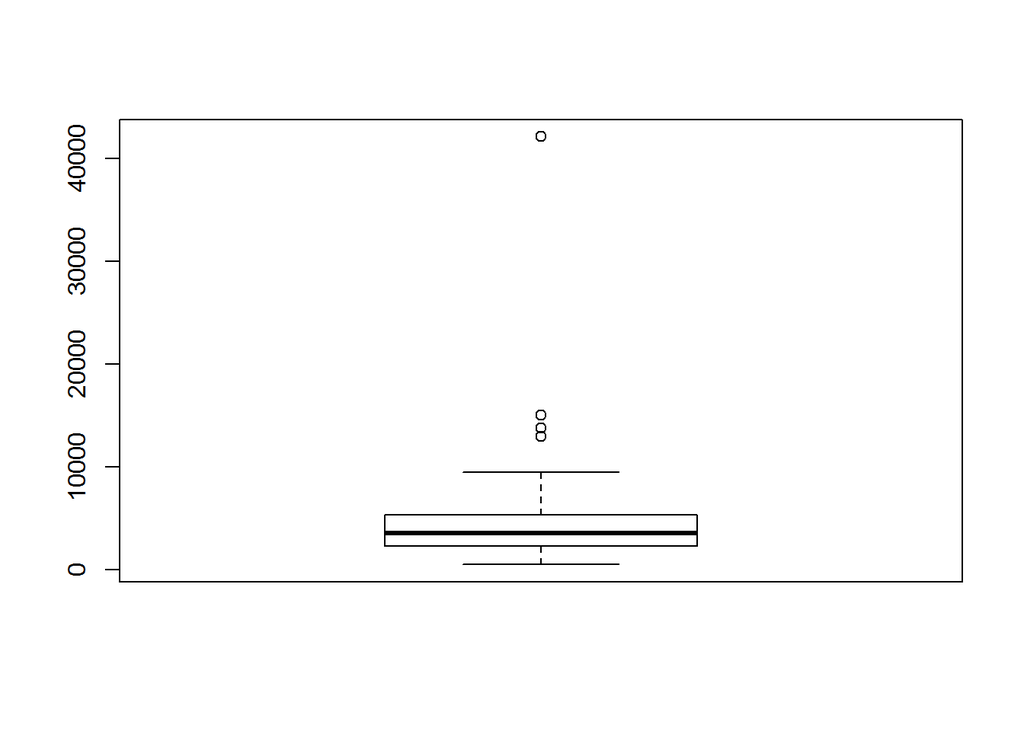

Temos quatro outliers, e um deles bem extravagante, ganhando acima de R$40000, como a média é uma medida sensível a seus valores, ela sofre um aumento graças a esses outliers.

Em termos gerais, o menor salário é R$ 500, o maior R$42120. Disconsiderando os outliers é uma distribuição bem próxima da esperada.

**4. Análise Sobre a Distribuição dos Salários**

Em partes sim, é uma distribuição similar que eu imaginava, o fato surpreendente é o do maior salário estar em Campina Grande, assim como ter tão poucas pessoas que ganham salários superiores a R$ 10000. Porém a maior faixa de salários é próximo do que eu imaginava.

**5. Média e Mediana de Salários**

A média

```
## Centro-oeste     Nordeste      Sudeste          Sul        Norte
##     5620.474     4565.706     3962.227     3657.538     2552.500
```

A média da região nordeste é bem alta, mas isso se deve ao outlier com o salário mais alto. Agora observando a mediana:

```
## Centro-oeste      Sudeste          Sul     Nordeste        Norte
##      5000.00      3582.95      3500.00      2900.00      2552.50
```

Analisando a mediana, como visto acima, temos uma informação mais real de um salário mediano de cada região, onde os outliers não influenciam tanto no valor.

Para salvar os dados:

`dados = sort(tapply(salarios.ti.regioes$Salario.Bruto, salarios.ti.regioes$Regiao, median), decreasing=TRUE)` `write.csv(dados, 'c:/Documentos/salario_por_regiao.csv')`

**6. Dicas Para a Busca do Melhor Salário**

Podemos olhar por alguns atributos, por estado por exemplo:

```
##     RJ     CE     DF     PJ     SC     GO     SP     PA     PB     RS
## 5250.0 5200.0 5100.0 4500.0 4400.0 4384.5 4300.0 4000.0 3900.0 3900.0
##     PR     BA     MT     MG     AL            ES     PE     SE     RO
## 3250.0 3000.0 2890.0 2508.0 2250.0 2125.0 2100.0 2035.0 1150.0 1105.0
```

Se formos fazer uma escolhar por estado, Rio de Janeiro, Ceará e Distrito Federal seriam as melhores opções.

Por região, como visto no tópico anterior

```
## Centro-oeste      Sudeste          Sul     Nordeste        Norte
##      5000.00      3582.95      3500.00      2900.00      2552.50
```

Nesse ponto o centro-oeste é disparado a melhor opção, porém lá possui o maior custo de vida do país e isso deve ser levado em consideração.

Ao fazer a análise por horas trabalhadas, podemos ver que não é um fator tão determinante assim para o salário.

```
##    7    9    8  8.8 8.48  8.4    6    4
## 5495 4650 3500 3500 3300 2900 1500 1100
```

Quando observamos certificação(ou pós graduação), vemos que este atributo tem uma relaçao muito grande com o salário, pessoas que o possuem, no geral ganham mais.

```
##  TRUE FALSE
##  4600  2850
```

```
##      12       3       9     3.5    2.83       4    0.83     2.5    0.25
## 15000.0  6000.0  6000.0  5800.0  5700.0  5200.0  5125.0  5062.5  5000.0
##    0.66     1.3    0.58    1.66       5       7       6       1    1.58
##  4450.0  4390.0  4300.0  4100.0  3990.0  3850.0  3665.9  3500.0  3500.0
##     0.5     5.5    0.16    0.33    1.91    2.66    1.16    0.08       2
##  3150.0  3100.0  3000.0  3000.0  2950.0  2890.0  2800.0  2504.0  2500.0
##    1.41    2.16    0.75    0.41       0
##  2400.0  2100.0  2050.0  1887.5   800.0
```